# Lab 2 Homework

Ritwik Varma

2023-01-18

## Instructions

Answer the following questions and complete the exercises in RMarkdown. Please embed all of your code and push your final work to your repository. Your final lab report should be organized, clean, and run free from errors. Remember, you must remove the `#` for the included code chunks to run. Be sure to add your name to the author header above.

Make sure to use the formatting conventions of RMarkdown to make your report neat and clean!

1. What is a vector in R?  
   A vector is a data structure that can hold numerics, integers, or strings and has the format object <- c(data) where the c means concatenate.
2. What is a data matrix in R?  
   A data matrix is two or more vectors combined to make a new data structure called a matrix.
3. Below are data collected by three scientists (Jill, Steve, Susan in order) measuring temperatures of eight hot springs. Run this code chunk to create the vectors.

```r
spring_1 <- c(36.25, 35.40, 35.30)
spring_2 <- c(35.15, 35.35, 33.35)
spring_3 <- c(30.70, 29.65, 29.20)
spring_4 <- c(39.70, 40.05, 38.65)
spring_5 <- c(31.85, 31.40, 29.30)
spring_6 <- c(30.20, 30.65, 29.75)
spring_7 <- c(32.90, 32.50, 32.80)
spring_8 <- c(36.80, 36.45, 33.15)
```

4. Build a data matrix that has the springs as rows and the columns as scientists.

```r
all_springs_temps <- c(spring_1, spring_2, spring_3, spring_4, spring_5, spring_6, spring_7, spring_8)
spring_matrix <- matrix(all_springs_temps,nrow=8, ncol=3, byrow=T)
spring_matrix
```

```
##       [,1]  [,2]  [,3]
## [1,] 36.25 35.40 35.30
## [2,] 35.15 35.35 33.35
## [3,] 30.70 29.65 29.20
## [4,] 39.70 40.05 38.65
## [5,] 31.85 31.40 29.30
## [6,] 30.20 30.65 29.75
## [7,] 32.90 32.50 32.80
## [8,] 36.80 36.45 33.15
```

5. The names of the springs are 1.Bluebell Spring, 2.Opal Spring, 3.Riverside Spring, 4.Too Hot Spring, 5.Mystery Spring, 6.Emerald Spring, 7.Black Spring, 8.Pearl Spring. Name the rows and columns in the data matrix. Start by making two new vectors with the names, then use `colnames()` and `rownames()` to name the columns and rows.

```r
spring_names <- c("Bluebell","Opal Spring", "Riverside Spring", "Too Hot Spring", "Mystery Spring", "Emerald Spring", "Black Spring", "Pearl Spring")
scientists <- c("Jill", "Steve", "Susan")
colnames(spring_matrix) <- scientists
rownames(spring_matrix) <- spring_names
spring_matrix
```

```
##                   Jill Steve Susan
## Bluebell         36.25 35.40 35.30
## Opal Spring      35.15 35.35 33.35
## Riverside Spring 30.70 29.65 29.20
## Too Hot Spring   39.70 40.05 38.65
## Mystery Spring   31.85 31.40 29.30
## Emerald Spring   30.20 30.65 29.75
## Black Spring     32.90 32.50 32.80
## Pearl Spring     36.80 36.45 33.15
```

6. Calculate the mean temperature of all eight springs.

```r
mean_temps <- rowSums(spring_matrix)/3
mean_temps
```

```
##         Bluebell      Opal Spring Riverside Spring   Too Hot Spring
##         35.65000         34.61667         29.85000         39.46667
##   Mystery Spring   Emerald Spring     Black Spring     Pearl Spring
##         30.85000         30.20000         32.73333         35.46667
```

7. Add this as a new column in the data matrix.

```r
spring_matrix_with_mean <- cbind(spring_matrix,mean_temps)
```

8. Show Susan’s value for Opal Spring only.

```r
spring_matrix_with_mean[2,3]
```

```
## [1] 33.35
```

9. Calculate the mean for Jill’s column only.

```r
jill_col <- spring_matrix_with_mean[,1]
mean(jill_col)
```

```
## [1] 34.19375
```

10. Use the data matrix to perform one calculation or operation of your interest.

```r
#my friend Hugo Moncada dictated the for loop code for me
stdev = NULL
for (i in 1:nrow(spring_matrix)){
  stdev [i]= sd(spring_matrix[i,])
}

newer_spring_matrix <- cbind(spring_matrix_with_mean, stdev)
```

```r
library("reshape2")

long_form_sm <- melt(spring_matrix_with_mean[,-c(4)])
long_form_sm
```

```
##                Var1  Var2 value
## 1          Bluebell  Jill 36.25
## 2       Opal Spring  Jill 35.15
## 3  Riverside Spring  Jill 30.70
## 4    Too Hot Spring  Jill 39.70
## 5    Mystery Spring  Jill 31.85
## 6    Emerald Spring  Jill 30.20
## 7      Black Spring  Jill 32.90
## 8      Pearl Spring  Jill 36.80
## 9          Bluebell Steve 35.40
## 10      Opal Spring Steve 35.35
## 11 Riverside Spring Steve 29.65
## 12   Too Hot Spring Steve 40.05
## 13   Mystery Spring Steve 31.40
## 14   Emerald Spring Steve 30.65
## 15     Black Spring Steve 32.50
## 16     Pearl Spring Steve 36.45
## 17         Bluebell Susan 35.30
## 18      Opal Spring Susan 33.35
## 19 Riverside Spring Susan 29.20
## 20   Too Hot Spring Susan 38.65
## 21   Mystery Spring Susan 29.30
## 22   Emerald Spring Susan 29.75
## 23     Black Spring Susan 32.80
## 24     Pearl Spring Susan 33.15
```

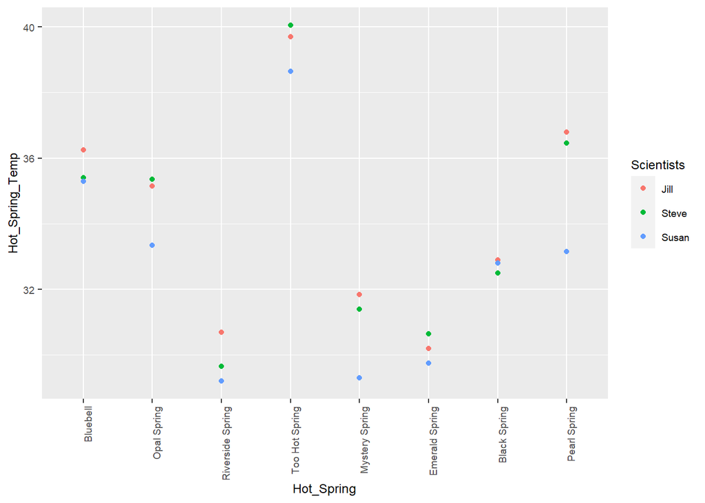

```r
names(long_form_sm) <- c("Hot_Spring", "Scientists","Hot_Spring_Temp")

library("ggplot2")
ggplot(long_form_sm, aes(x=Hot_Spring, y=Hot_Spring_Temp, colour=Scientists)) +
  geom_point() +
  theme(text = element_text(size=9),
        axis.text.x = element_text(angle=90, hjust=1))
```

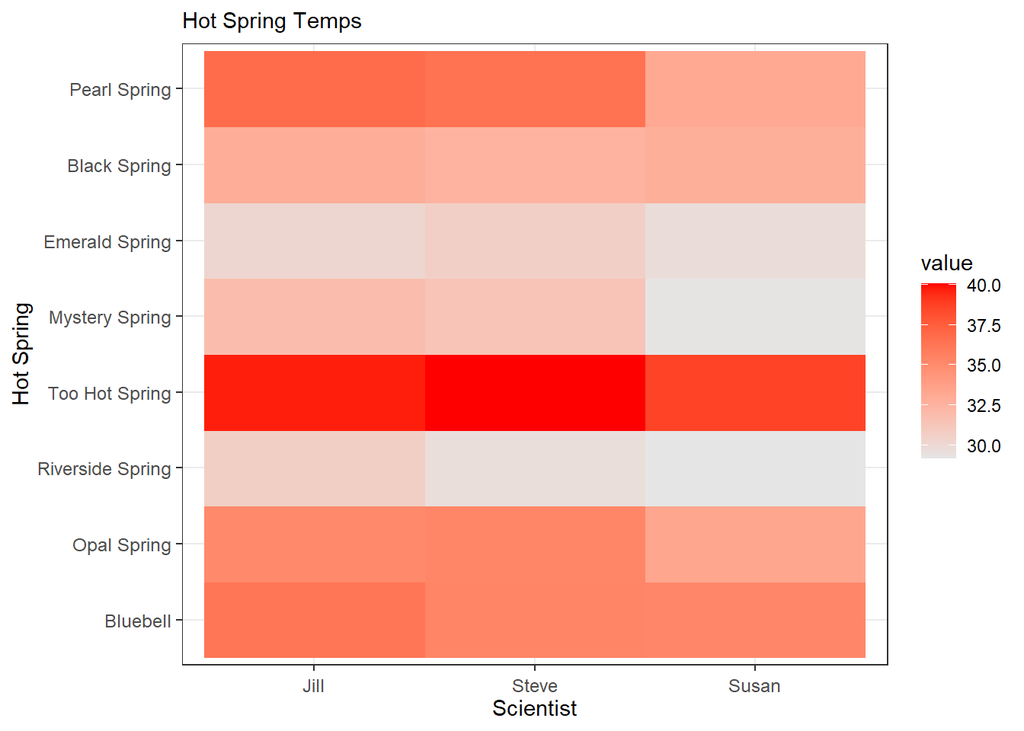

```r
#I found this code on the internet and changed it to fit our situation

library(reshape2)
library(ggplot2)

longData<-melt(spring_matrix)
longData<-longData[longData$value!=0,]

ggplot(longData, aes(x = Var2, y = Var1)) +
  geom_raster(aes(fill=value)) +
  scale_fill_gradient(low="grey90", high="red") +
  labs(x="Scientist", y="Hot Spring", title="Hot Spring Temps") +
  theme_bw() + theme(axis.text.x=element_text(size=9, angle=0, vjust=0.3),
                     axis.text.y=element_text(size=9),
                     plot.title=element_text(size=11))
```

## Push your final code to GitHub!

Please be sure that you check the `keep md` file in the knit preferences.